# Question

A simple piece-wise function $f$ is plotted below.

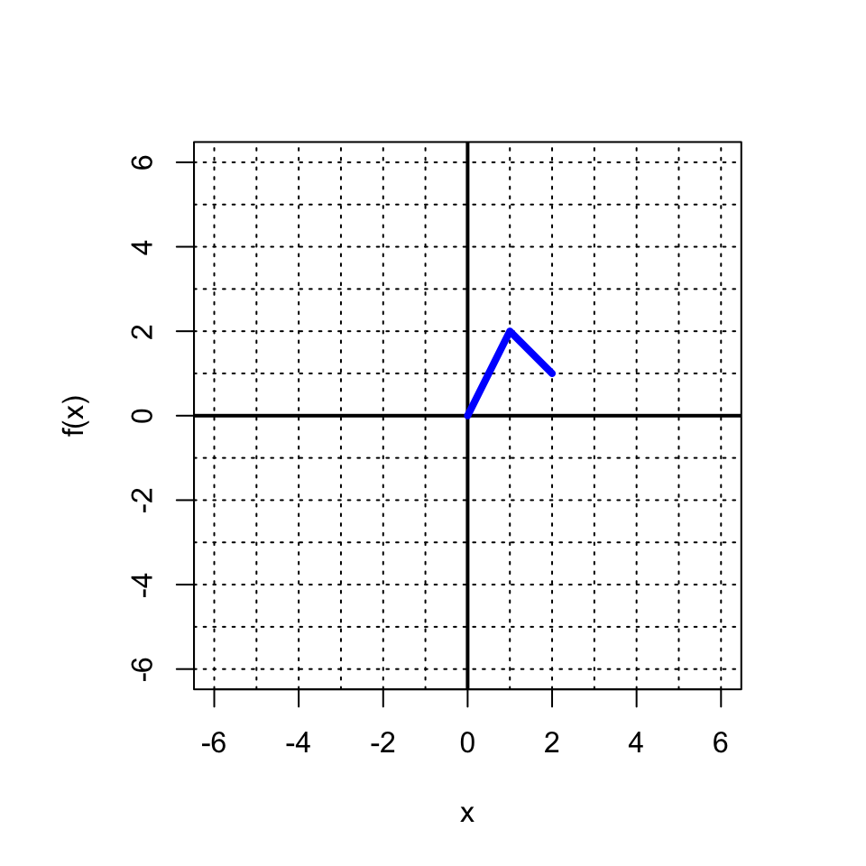

It’s general daughter function, having translations, reflections, and stretches, can be expressed with 4 parameters: $a$, $b$, $h$, and $k$.

$$g(x) = a\, f(b(x-h))+k$$

Compared to the parent function, the daughter is stretched vertically by a factor of $a$, stretch horizontally by a factor of $\frac{1}{b}$, and then shifted right $h$ and up $k$.

Notice, a left or down shift gives a negative value for $h$ or $k$. Also, a negative stretch factor causes a reflection.

Each of those four parameters is randomly assigned $\pm 2$ or $\pm \frac{1}{2}$. Determine the four parameters of the daughter by inspecting the daughter’s graph:

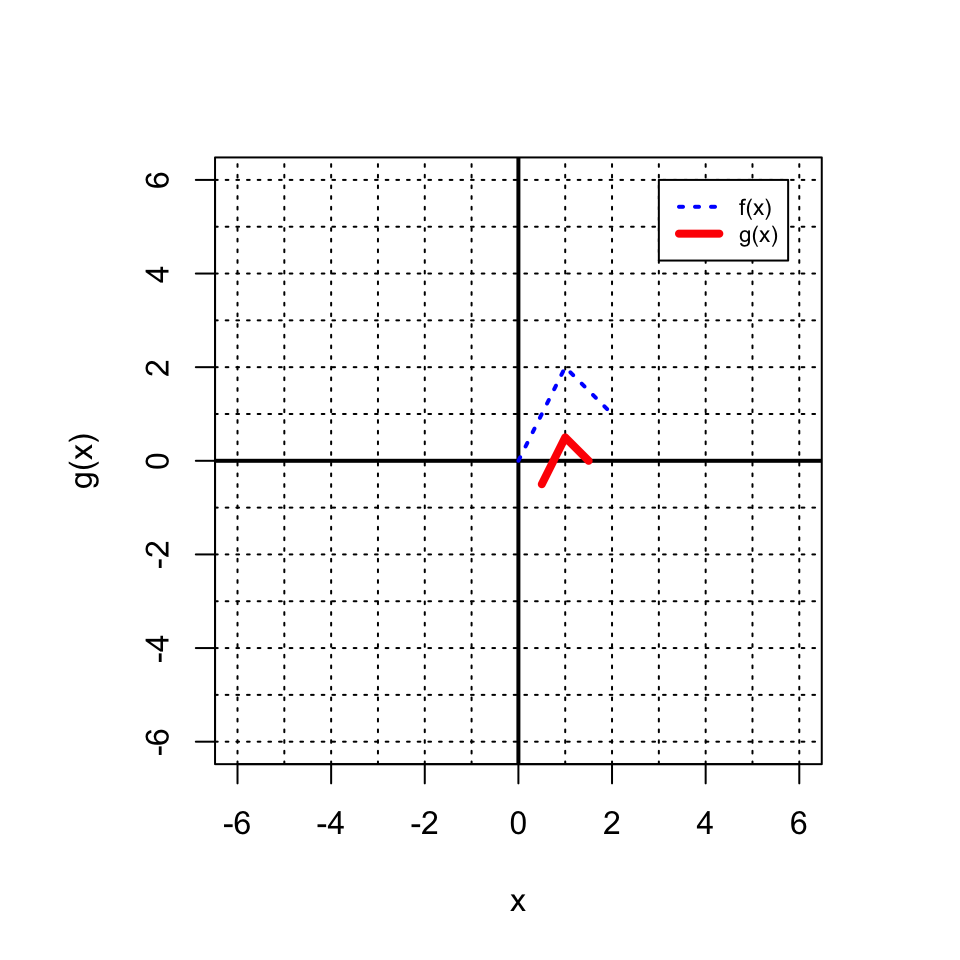

- $a =$ ##ANSWER1##
- $b =$ ##ANSWER2##
- $h =$ ##ANSWER3##
- $k =$ ##ANSWER4##

Also, write the equation to define the daughter.

$g(x) =$ ##ANSWER5## $f($ ##ANSWER6## $(x$ ##ANSWER7## $)$ ##ANSWER8##

## Answerlist

- -2
- -1/2
- 1/2
- 2
- -2
- -1/2
- 1/2
- 2
- -2
- -1/2
- 1/2
- 2
- -2
- -1/2
- 1/2
- 2
- -2
- -1/2
- 1/2
- 2
- -2
- -1/2
- 1/2
- 2
- -2
- -1/2
- +1/2
- +2
- -2
- -1/2
- +1/2
- +2

# Solution

- The daughter is stretched vertically by a factor of 0.5, so $a=0.5$.
- The daughter is stretched horizontally by a factor of 0.5, so $b=2$.
- The parent’s origin (free end of long segment), is shifted to (0.5, -0.5), so $h=0.5$ and $k=-0.5$.

When we put those parameters into definition of $g$, we get:
$$g(x) = 0.5\,f(2(x-0.5))-0.5$$

Personally, I find it most interesting that the horizontal transformations occur **REVERSE** PEMDAS. Most people would guess, using order of operations, that the horizontal translation by $h$ would occur before the horizontal stretch by $\frac{1}{b}$, but this would be wrong. You might remember that applying inverse operations in reverse PEMDAS is what we do to solve equations in Algebra.

# Meta-information

extype: cloze exclozetype: schoice|schoice|schoice|schoice|schoice|schoice|schoice|schoice exsolution: 0010|0001|0010|0100|0010|0001|0100|0100 exname: translate_and_stretch